# PAVANKALYANB_10-Dec-2021-Mcdonalds_assignment

# Inference

## No outlier

# 3- Which variables have the highest correlation? Plot them and find out the value?

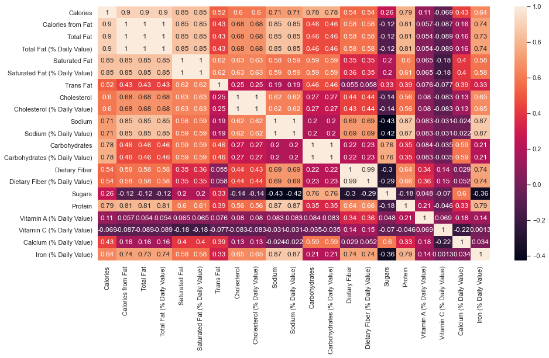

```python
correlation = mydata.corr()
plt.figure(figsize=(15,8))
sns.heatmap(correlation,annot=True);
```

# 4- Which category contributes to the maximum % of Cholesterol in a diet (% daily value)?

```python
df = pd.pivot_table(data=mydata,values='Cholesterol (% Daily Value)',index='Category')
df.sort_values('Cholesterol (% Daily Value)',ascending=False)
```

| Category | Cholesterol (% Daily Value) |
| --- | --- |
| Breakfast | 50.952381 |
| Beef & Pork | 28.933333 |
| Chicken & Fish | 25.222222 |
| Salads | 17.333333 |
| Smoothies & Shakes | 14.714286 |
| Coffee & Tea | 9.378947 |
| Snacks & Sides | 6.230769 |
| Desserts | 4.857143 |
| Beverages | 0.185185 |

### The category which contributes to the maximum % of cholestrol in a diet (% daily value) is below

- Breakfast

# 5- Which item contributes maximum to the Sodium intake?

```python
df = pd.pivot_table(data=mydata,values='Sodium',index='Item')
df.sort_values('Sodium',ascending=False)
```

| Item | Sodium |
| --- | --- |
| Chicken McNuggets (40 piece) | 3600 |
| Big Breakfast with Hotcakes and Egg Whites (Large Biscuit) | 2290 |
| Big Breakfast with Hotcakes (Large Biscuit) | 2260 |
| Big Breakfast with Hotcakes and Egg Whites (Regular Biscuit) | 2170 |
| Big Breakfast with Hotcakes (Regular Biscuit) | 2150 |
| ... | ... |
| Coca-Cola Classic (Child) | 0 |
| Dasani Water Bottle | 0 |
| Minute Maid Orange Juice (Medium) | 0 |
| Apple Slices | 0 |
| Minute Maid Orange Juice (Small) | 0 |

260 rows × 1 columns

### The item which contributes maximum to the sodium intake is below

- Chicken McNuggets (40 piece)

# 6- Which 4 food items contain the most amount of Saturated Fat?

```python
df = pd.pivot_table(data=mydata,values='Saturated Fat',index='Item')
df.sort_values('Saturated Fat',ascending=False).head(4)
```

| Item | Saturated Fat |
| --- | --- |
| McFlurry with M&M’s Candies (Medium) | 20.0 |
| Big Breakfast with Hotcakes (Large Biscuit) | 20.0 |
| Chicken McNuggets (40 piece) | 20.0 |
| Frappé Chocolate Chip (Large) | 20.0 |

### The 4 food items that contain the most amount of saturated fat is below

- McFlurry with M&M’s Candies (Medium)
- Big Breakfast with Hotcakes (Large Biscuit)
- Chicken McNuggets (40 piece)
- Frappé Chocolate Chip (Large)